# R_For_Data_Science_Notes

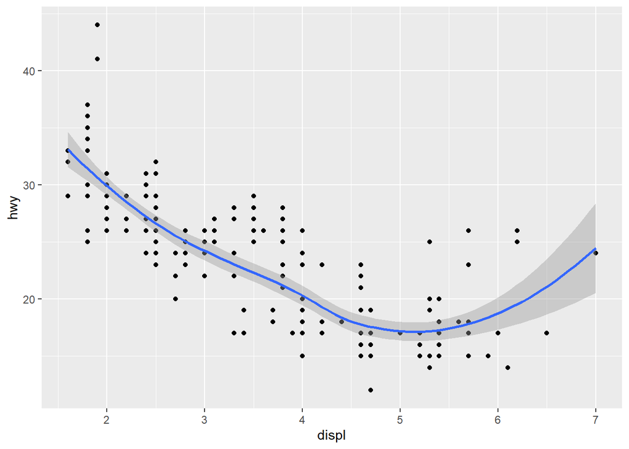

```r
ggplot(data = mpg) + geom_point(mapping = aes(x = displ, y = hwy)) + geom_smooth(mapping = aes(x = displ, y = hwy))
```

We can get rid of the duplication by using the following code instead

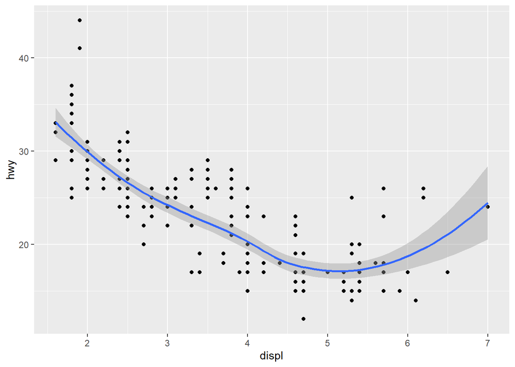

```r
ggplot(data = mpg, mapping = aes(x = displ, y = hwy)) + geom_point() + geom_smooth()
```

If we were to add a mapping tpa a geom function, it will add it to that layer only. This makes it possible to display different aesthetics in different layers

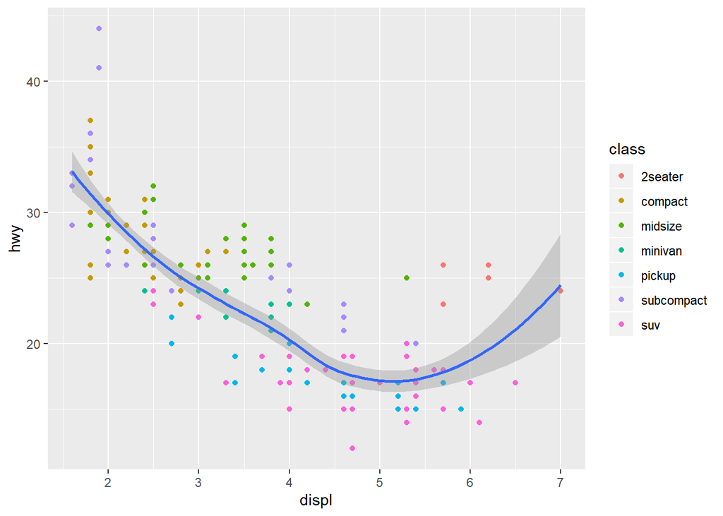

```r
ggplot(data = mpg, mapping = aes(x = displ, y = hwy)) + geom_point(mapping = aes(color = class)) + geom_smooth()
```

We can also specify data for each layer. Here, our smooth line displays just a subset of the mpg dataset, the subcompact cars. The local argument in geom_smooth() overrides the global argument in ggplot() for that layer only. We need to load dplyr package for the filter() function to work.

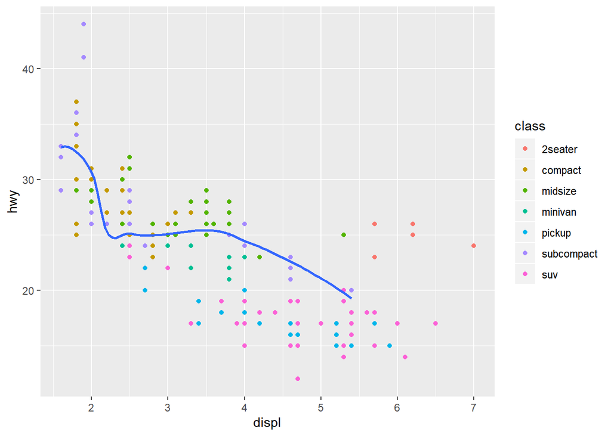

```r
library(dplyr)
ggplot(data = mpg, mapping = aes(x = displ, y = hwy)) + geom_point(mapping = aes(color = class)) + geom_smooth(data = filter(mpg, class == "subcompact"), se = FALSE)
```